# Optimal Treatment Analysis

## Outcome Variable

**Outcome Variable:** whz

## Predictor Variables

**Intervention Variable:** month

**Adjustment Set:**

unadjusted

## Stratifying Variables

The analysis was stratified on these variable(s):

- agecat
- studyid
- country

## Data Summary

| agecat | studyid | country | month | n_cell | n |
| --- | --- | --- | --- | --- | --- |
| Birth | ki0047075b-MAL-ED | BANGLADESH | 1 | 19 | 241 |
| Birth | ki0047075b-MAL-ED | BANGLADESH | 2 | 21 | 241 |
| Birth | ki0047075b-MAL-ED | BANGLADESH | 3 | 25 | 241 |
| Birth | ki0047075b-MAL-ED | BANGLADESH | 4 | 21 | 241 |
| Birth | ki0047075b-MAL-ED | BANGLADESH | 5 | 20 | 241 |
| Birth | ki0047075b-MAL-ED | BANGLADESH | 6 | 8 | 241 |
| Birth | ki0047075b-MAL-ED | BANGLADESH | 7 | 21 | 241 |
| Birth | ki0047075b-MAL-ED | BANGLADESH | 8 | 22 | 241 |
| Birth | ki0047075b-MAL-ED | BANGLADESH | 9 | 20 | 241 |
| Birth | ki0047075b-MAL-ED | BANGLADESH | 10 | 23 | 241 |
| Birth | ki0047075b-MAL-ED | BANGLADESH | 11 | 15 | 241 |
| Birth | ki0047075b-MAL-ED | BANGLADESH | 12 | 26 | 241 |
| Birth | ki0047075b-MAL-ED | BRAZIL | 1 | 9 | 183 |
| Birth | ki0047075b-MAL-ED | BRAZIL | 2 | 19 | 183 |
| Birth | ki0047075b-MAL-ED | BRAZIL | 3 | 17 | 183 |
| Birth | ki0047075b-MAL-ED | BRAZIL | 4 | 8 | 183 |
| Birth | ki0047075b-MAL-ED | BRAZIL | 5 | 16 | 183 |
| Birth | ki0047075b-MAL-ED | BRAZIL | 6 | 7 | 183 |
| Birth | ki0047075b-MAL-ED | BRAZIL | 7 | 17 | 183 |
| Birth | ki0047075b-MAL-ED | BRAZIL | 8 | 17 | 183 |
| Birth | ki0047075b-MAL-ED | BRAZIL | 9 | 27 | 183 |
| Birth | ki0047075b-MAL-ED | BRAZIL | 10 | 18 | 183 |
| Birth | ki0047075b-MAL-ED | BRAZIL | 11 | 15 | 183 |
| Birth | ki0047075b-MAL-ED | BRAZIL | 12 | 13 | 183 |
| Birth | ki0047075b-MAL-ED | INDIA | 1 | 16 | 203 |
| Birth | ki0047075b-MAL-ED | INDIA | 2 | 16 | 203 |
| Birth | ki0047075b-MAL-ED | INDIA | 3 | 20 | 203 |
| Birth | ki0047075b-MAL-ED | INDIA | 4 | 14 | 203 |
| Birth | ki0047075b-MAL-ED | INDIA | 5 | 7 | 203 |
| Birth | ki0047075b-MAL-ED | INDIA | 6 | 17 | 203 |

[output cut: 798 more lines]

The following strata were considered:

- agecat: 24 months, studyid: ki0047075b-MAL-ED, country: BANGLADESH
- agecat: 24 months, studyid: ki0047075b-MAL-ED, country: BRAZIL
- agecat: 24 months, studyid: ki0047075b-MAL-ED, country: INDIA
- agecat: 24 months, studyid: ki0047075b-MAL-ED, country: NEPAL
- agecat: 24 months, studyid: ki0047075b-MAL-ED, country: PERU
- agecat: 24 months, studyid: ki0047075b-MAL-ED, country: SOUTH AFRICA
- agecat: 24 months, studyid: ki0047075b-MAL-ED, country: TANZANIA, UNITED REPUBLIC OF
- agecat: 24 months, studyid: ki1000108-CMC-V-BCS-2002, country: INDIA
- agecat: 24 months, studyid: ki1000108-IRC, country: INDIA
- agecat: 24 months, studyid: ki1017093-NIH-Birth, country: BANGLADESH
- agecat: 24 months, studyid: ki1066203-TanzaniaChild2, country: TANZANIA, UNITED REPUBLIC OF
- agecat: 24 months, studyid: ki1113344-GMS-Nepal, country: NEPAL
- agecat: 24 months, studyid: ki1114097-CMIN, country: BANGLADESH
- agecat: 24 months, studyid: ki1114097-CMIN, country: GUINEA-BISSAU
- agecat: 24 months, studyid: ki1114097-CMIN, country: PERU
- agecat: 24 months, studyid: ki1114097-CONTENT, country: PERU
- agecat: 24 months, studyid: ki1119695-PROBIT, country: BELARUS
- agecat: 24 months, studyid: ki1126311-ZVITAMBO, country: ZIMBABWE
- agecat: 24 months, studyid: ki1148112-LCNI-5, country: MALAWI
- agecat: 24 months, studyid: kiGH5241-JiVitA-3, country: BANGLADESH
- agecat: 24 months, studyid: kiGH5241-JiVitA-4, country: BANGLADESH
- agecat: 6 months, studyid: ki0047075b-MAL-ED, country: BANGLADESH
- agecat: 6 months, studyid: ki0047075b-MAL-ED, country: BRAZIL
- agecat: 6 months, studyid: ki0047075b-MAL-ED, country: INDIA
- agecat: 6 months, studyid: ki0047075b-MAL-ED, country: NEPAL
- agecat: 6 months, studyid: ki0047075b-MAL-ED, country: PERU
- agecat: 6 months, studyid: ki0047075b-MAL-ED, country: SOUTH AFRICA
- agecat: 6 months, studyid: ki0047075b-MAL-ED, country: TANZANIA, UNITED REPUBLIC OF
- agecat: 6 months, studyid: ki1000108-CMC-V-BCS-2002, country: INDIA
- agecat: 6 months, studyid: ki1000108-IRC, country: INDIA
- agecat: 6 months, studyid: ki1000109-EE, country: PAKISTAN
- agecat: 6 months, studyid: ki1000109-ResPak, country: PAKISTAN
- agecat: 6 months, studyid: ki1000304b-SAS-CompFeed, country: INDIA
- agecat: 6 months, studyid: ki1000304b-SAS-FoodSuppl, country: INDIA
- agecat: 6 months, studyid: ki1017093-NIH-Birth, country: BANGLADESH
- agecat: 6 months, studyid: ki1066203-TanzaniaChild2, country: TANZANIA, UNITED REPUBLIC OF
- agecat: 6 months, studyid: ki1112895-Guatemala BSC, country: GUATEMALA
- agecat: 6 months, studyid: ki1113344-GMS-Nepal, country: NEPAL
- agecat: 6 months, studyid: ki1114097-CMIN, country: BANGLADESH
- agecat: 6 months, studyid: ki1114097-CMIN, country: BRAZIL
- agecat: 6 months, studyid: ki1114097-CMIN, country: GUINEA-BISSAU
- agecat: 6 months, studyid: ki1114097-CMIN, country: PERU
- agecat: 6 months, studyid: ki1114097-CONTENT, country: PERU
- agecat: 6 months, studyid: ki1119695-PROBIT, country: BELARUS
- agecat: 6 months, studyid: ki1126311-ZVITAMBO, country: ZIMBABWE
- agecat: 6 months, studyid: ki1148112-LCNI-5, country: MALAWI
- agecat: 6 months, studyid: kiGH5241-JiVitA-3, country: BANGLADESH
- agecat: 6 months, studyid: kiGH5241-JiVitA-4, country: BANGLADESH
- agecat: Birth, studyid: ki0047075b-MAL-ED, country: BANGLADESH
- agecat: Birth, studyid: ki0047075b-MAL-ED, country: BRAZIL
- agecat: Birth, studyid: ki0047075b-MAL-ED, country: INDIA
- agecat: Birth, studyid: ki0047075b-MAL-ED, country: NEPAL
- agecat: Birth, studyid: ki0047075b-MAL-ED, country: PERU
- agecat: Birth, studyid: ki0047075b-MAL-ED, country: SOUTH AFRICA
- agecat: Birth, studyid: ki0047075b-MAL-ED, country: TANZANIA, UNITED REPUBLIC OF
- agecat: Birth, studyid: ki1000108-CMC-V-BCS-2002, country: INDIA
- agecat: Birth, studyid: ki1000108-IRC, country: INDIA
- agecat: Birth, studyid: ki1000109-EE, country: PAKISTAN
- agecat: Birth, studyid: ki1000109-ResPak, country: PAKISTAN
- agecat: Birth, studyid: ki1000304b-SAS-CompFeed, country: INDIA
- agecat: Birth, studyid: ki1017093-NIH-Birth, country: BANGLADESH
- agecat: Birth, studyid: ki1114097-CMIN, country: BANGLADESH
- agecat: Birth, studyid: ki1114097-CMIN, country: BRAZIL
- agecat: Birth, studyid: ki1114097-CMIN, country: PERU
- agecat: Birth, studyid: ki1114097-CONTENT, country: PERU
- agecat: Birth, studyid: ki1119695-PROBIT, country: BELARUS
- agecat: Birth, studyid: ki1126311-ZVITAMBO, country: ZIMBABWE
- agecat: Birth, studyid: kiGH5241-JiVitA-3, country: BANGLADESH
- agecat: Birth, studyid: kiGH5241-JiVitA-4, country: BANGLADESH

### Dropped Strata

Some strata were dropped due to rare outcomes:

- agecat: Birth, studyid: ki0047075b-MAL-ED, country: TANZANIA, UNITED REPUBLIC OF
- agecat: Birth, studyid: ki1000108-CMC-V-BCS-2002, country: INDIA
- agecat: Birth, studyid: ki1000109-EE, country: PAKISTAN
- agecat: Birth, studyid: ki1000109-ResPak, country: PAKISTAN
- agecat: Birth, studyid: ki1017093-NIH-Birth, country: BANGLADESH
- agecat: Birth, studyid: ki1114097-CMIN, country: BANGLADESH
- agecat: Birth, studyid: ki1114097-CMIN, country: BRAZIL
- agecat: Birth, studyid: ki1114097-CMIN, country: PERU
- agecat: Birth, studyid: ki1114097-CONTENT, country: PERU
- agecat: Birth, studyid: kiGH5241-JiVitA-4, country: BANGLADESH
- agecat: 6 months, studyid: ki1000109-EE, country: PAKISTAN
- agecat: 6 months, studyid: ki1000109-ResPak, country: PAKISTAN
- agecat: 6 months, studyid: ki1000304b-SAS-FoodSuppl, country: INDIA
- agecat: 6 months, studyid: ki1113344-GMS-Nepal, country: NEPAL
- agecat: 6 months, studyid: ki1114097-CMIN, country: BANGLADESH
- agecat: 6 months, studyid: ki1114097-CMIN, country: BRAZIL
- agecat: 24 months, studyid: ki1066203-TanzaniaChild2, country: TANZANIA, UNITED REPUBLIC OF
- agecat: 24 months, studyid: ki1113344-GMS-Nepal, country: NEPAL
- agecat: 24 months, studyid: ki1114097-CMIN, country: BANGLADESH
- agecat: 24 months, studyid: ki1114097-CONTENT, country: PERU
- agecat: 24 months, studyid: ki1126311-ZVITAMBO, country: ZIMBABWE

## Methods Detail

We’re interested in the causal parameters $E[Y_a]$ for all values of $a \in \mathcal{A}$. These parameters represent the mean outcome if, possibly contrary to fact, we intervened to set all units to have $A=a$. Under the randomization and positivity assumptions, these are identified by the statistical parameters $\psi_a=E_W[E_{Y|A,W}(Y|A=a,W)]$. In addition, we’re interested in the mean of $Y$, $E[Y]$ under no intervention (the observed mean). We will estimate these parameters by using SuperLearner to fit the relevant likelihood factors – $E_{Y|A,W}(Y|A=a,W)$ and $p(A=a|W)$, and then updating our likelihood fit using a joint TMLE.

For unadjusted analyses ($W=\{\}$), initial likelihoods were estimated using Lrnr_glm to estimate the simple $E(Y|A)$ and Lrnr_mean to estimate $p(A)$. For adjusted analyses, a small library containing Lrnr_glmnet, Lrnr_xgboost, and Lrnr_mean was used.

Having estimated these parameters, we will then use the delta method to estimate relative risks and attributable risks relative to a prespecified baseline level of $A$.

# Results Detail

## Results Plots

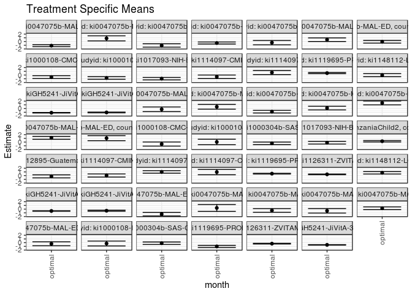

## Results Table

### Parameter: TSM

| agecat | studyid | country | intervention_level | baseline_level | estimate | ci_lower | ci_upper |
| --- | --- | --- | --- | --- | --- | --- | --- |
| Birth | ki0047075b-MAL-ED | BANGLADESH | optimal | observed | -1.3474144 | -1.8315694 | -0.8632594 |
| Birth | ki0047075b-MAL-ED | BRAZIL | optimal | observed | 0.3214293 | -0.6056284 | 1.2484871 |
| Birth | ki0047075b-MAL-ED | INDIA | optimal | observed | -0.3508073 | -0.8464455 | 0.1448309 |
| Birth | ki0047075b-MAL-ED | NEPAL | optimal | observed | -0.4488511 | -1.0511453 | 0.1534431 |
| Birth | ki0047075b-MAL-ED | PERU | optimal | observed | 0.2348133 | -0.1383652 | 0.6079918 |
| Birth | ki0047075b-MAL-ED | SOUTH AFRICA | optimal | observed | -0.2987283 | -0.8345799 | 0.2371232 |
| Birth | ki1000108-IRC | INDIA | optimal | observed | -0.2223829 | -0.8801439 | 0.4353781 |
| Birth | ki1000304b-SAS-CompFeed | INDIA | optimal | observed | -0.1456334 | -0.4771630 | 0.1858961 |
| Birth | ki1119695-PROBIT | BELARUS | optimal | observed | -1.0144446 | -1.3016168 | -0.7272724 |
| Birth | ki1126311-ZVITAMBO | ZIMBABWE | optimal | observed | -0.2648428 | -0.3611599 | -0.1685258 |
| Birth | kiGH5241-JiVitA-3 | BANGLADESH | optimal | observed | -0.5912298 | -0.6492152 | -0.5332444 |
| 6 months | ki0047075b-MAL-ED | BANGLADESH | optimal | observed | -0.1975923 | -0.8262862 | 0.4311015 |
| 6 months | ki0047075b-MAL-ED | BRAZIL | optimal | observed | 0.4774277 | -0.1648269 | 1.1196824 |
| 6 months | ki0047075b-MAL-ED | INDIA | optimal | observed | -0.8398586 | -1.1990802 | -0.4806369 |
| 6 months | ki0047075b-MAL-ED | NEPAL | optimal | observed | 0.1347031 | -0.3622170 | 0.6316231 |
| 6 months | ki0047075b-MAL-ED | PERU | optimal | observed | 1.5095994 | 0.9907363 | 2.0284624 |
| 6 months | ki0047075b-MAL-ED | SOUTH AFRICA | optimal | observed | 1.1472081 | 0.7564235 | 1.5379928 |
| 6 months | ki0047075b-MAL-ED | TANZANIA, UNITED REPUBLIC OF | optimal | observed | 1.0528096 | 0.3735823 | 1.7320369 |
| 6 months | ki1000108-CMC-V-BCS-2002 | INDIA | optimal | observed | -0.5256912 | -1.0769363 | 0.0255540 |
| 6 months | ki1000108-IRC | INDIA | optimal | observed | 0.0304426 | -0.7107114 | 0.7715967 |
| 6 months | ki1000304b-SAS-CompFeed | INDIA | optimal | observed | -0.3378347 | -0.6848812 | 0.0092117 |
| 6 months | ki1017093-NIH-Birth | BANGLADESH | optimal | observed | -0.1614896 | -0.5246551 | 0.2016760 |
| 6 months | ki1066203-TanzaniaChild2 | TANZANIA, UNITED REPUBLIC OF | optimal | observed | 0.2314962 | 0.0393656 | 0.4236269 |
| 6 months | ki1112895-Guatemala BSC | GUATEMALA | optimal | observed | -0.2051344 | -0.6154072 | 0.2051383 |
| 6 months | ki1114097-CMIN | GUINEA-BISSAU | optimal | observed | 0.0321065 | -0.3863935 | 0.4506065 |
| 6 months | ki1114097-CMIN | PERU | optimal | observed | 0.9972838 | 0.6602220 | 1.3343456 |
| 6 months | ki1114097-CONTENT | PERU | optimal | observed | 0.9508024 | 0.2301098 | 1.6714950 |
| 6 months | ki1119695-PROBIT | BELARUS | optimal | observed | 0.5278038 | 0.4357453 | 0.6198623 |
| 6 months | ki1126311-ZVITAMBO | ZIMBABWE | optimal | observed | 0.3396554 | 0.2448632 | 0.4344476 |
| 6 months | ki1148112-LCNI-5 | MALAWI | optimal | observed | 0.7658019 | 0.4347455 | 1.0968583 |
| 6 months | kiGH5241-JiVitA-3 | BANGLADESH | optimal | observed | -0.4955660 | -0.5675411 | -0.4235910 |
| 6 months | kiGH5241-JiVitA-4 | BANGLADESH | optimal | observed | -0.4207723 | -0.5619842 | -0.2795603 |
| 24 months | ki0047075b-MAL-ED | BANGLADESH | optimal | observed | -1.1207598 | -1.3884797 | -0.8530398 |
| 24 months | ki0047075b-MAL-ED | BRAZIL | optimal | observed | 0.8460073 | 0.1633813 | 1.5286334 |
| 24 months | ki0047075b-MAL-ED | INDIA | optimal | observed | -1.0613882 | -1.5145243 | -0.6082522 |
| 24 months | ki0047075b-MAL-ED | NEPAL | optimal | observed | -0.4052450 | -0.6764044 | -0.1340856 |
| 24 months | ki0047075b-MAL-ED | PERU | optimal | observed | -0.3069714 | -0.8888113 | 0.2748685 |
| 24 months | ki0047075b-MAL-ED | SOUTH AFRICA | optimal | observed | 0.4911131 | 0.0079409 | 0.9742854 |
| 24 months | ki0047075b-MAL-ED | TANZANIA, UNITED REPUBLIC OF | optimal | observed | -0.0685296 | -0.4273494 | 0.2902902 |
| 24 months | ki1000108-CMC-V-BCS-2002 | INDIA | optimal | observed | -0.5606777 | -0.9474894 | -0.1738661 |
| 24 months | ki1000108-IRC | INDIA | optimal | observed | -0.7898558 | -1.1355894 | -0.4441222 |
| 24 months | ki1017093-NIH-Birth | BANGLADESH | optimal | observed | -0.9761660 | -1.3043069 | -0.6480251 |
| 24 months | ki1114097-CMIN | GUINEA-BISSAU | optimal | observed | -0.4745058 | -0.9518084 | 0.0027968 |
| 24 months | ki1114097-CMIN | PERU | optimal | observed | 0.6612689 | 0.1164328 | 1.2061050 |
| 24 months | ki1119695-PROBIT | BELARUS | optimal | observed | 0.5204585 | 0.3650350 | 0.6758820 |
| 24 months | ki1148112-LCNI-5 | MALAWI | optimal | observed | -0.0357373 | -0.4565996 | 0.3851250 |
| 24 months | kiGH5241-JiVitA-3 | BANGLADESH | optimal | observed | -1.1221260 | -1.1927531 | -1.0514988 |
| 24 months | kiGH5241-JiVitA-4 | BANGLADESH | optimal | observed | -1.0467403 | -1.1528414 | -0.9406392 |

### Parameter: E(Y)

| agecat | studyid | country | intervention_level | baseline_level | estimate | ci_lower | ci_upper |
| --- | --- | --- | --- | --- | --- | --- | --- |
| Birth | ki0047075b-MAL-ED | BANGLADESH | observed | observed | -0.9630705 | -1.0989132 | -0.8272278 |
| Birth | ki0047075b-MAL-ED | BRAZIL | observed | observed | 0.4038798 | 0.2296279 | 0.5781316 |
| Birth | ki0047075b-MAL-ED | INDIA | observed | observed | -1.0691133 | -1.2078629 | -0.9303637 |
| Birth | ki0047075b-MAL-ED | NEPAL | observed | observed | -0.9044643 | -1.0439568 | -0.7649718 |
| Birth | ki0047075b-MAL-ED | PERU | observed | observed | -0.0735842 | -0.1836203 | 0.0364518 |
| Birth | ki0047075b-MAL-ED | SOUTH AFRICA | observed | observed | -0.0562791 | -0.2000837 | 0.0875255 |
| Birth | ki1000108-IRC | INDIA | observed | observed | -1.0105831 | -1.1973019 | -0.8238643 |
| Birth | ki1000304b-SAS-CompFeed | INDIA | observed | observed | -0.2697590 | -0.5399211 | 0.0004030 |
| Birth | ki1119695-PROBIT | BELARUS | observed | observed | -1.1463469 | -1.3562674 | -0.9364264 |
| Birth | ki1126311-ZVITAMBO | ZIMBABWE | observed | observed | -0.5149267 | -0.5408101 | -0.4890433 |
| Birth | kiGH5241-JiVitA-3 | BANGLADESH | observed | observed | -0.7240996 | -0.7439385 | -0.7042607 |
| 6 months | ki0047075b-MAL-ED | BANGLADESH | observed | observed | -0.1397960 | -0.2688682 | -0.0107238 |
| 6 months | ki0047075b-MAL-ED | BRAZIL | observed | observed | 0.9717225 | 0.8073791 | 1.1360658 |
| 6 months | ki0047075b-MAL-ED | INDIA | observed | observed | -0.7033969 | -0.8285284 | -0.5782654 |
| 6 months | ki0047075b-MAL-ED | NEPAL | observed | observed | 0.1110452 | -0.0202712 | 0.2423616 |
| 6 months | ki0047075b-MAL-ED | PERU | observed | observed | 1.0543956 | 0.9326967 | 1.1760945 |
| 6 months | ki0047075b-MAL-ED | SOUTH AFRICA | observed | observed | 0.5420735 | 0.3899459 | 0.6942011 |
| 6 months | ki0047075b-MAL-ED | TANZANIA, UNITED REPUBLIC OF | observed | observed | 0.5170513 | 0.3872178 | 0.6468847 |
| 6 months | ki1000108-CMC-V-BCS-2002 | INDIA | observed | observed | -0.5026766 | -0.6536848 | -0.3516685 |
| 6 months | ki1000108-IRC | INDIA | observed | observed | -0.5989297 | -0.7344491 | -0.4634104 |
| 6 months | ki1000304b-SAS-CompFeed | INDIA | observed | observed | -0.6657084 | -0.8024377 | -0.5289791 |
| 6 months | ki1017093-NIH-Birth | BANGLADESH | observed | observed | -0.4389101 | -0.5279432 | -0.3498771 |
| 6 months | ki1066203-TanzaniaChild2 | TANZANIA, UNITED REPUBLIC OF | observed | observed | 0.0809332 | 0.0282644 | 0.1336020 |
| 6 months | ki1112895-Guatemala BSC | GUATEMALA | observed | observed | -0.0840134 | -0.1945572 | 0.0265305 |
| 6 months | ki1114097-CMIN | GUINEA-BISSAU | observed | observed | -0.0418080 | -0.1199942 | 0.0363782 |
| 6 months | ki1114097-CMIN | PERU | observed | observed | 0.6721017 | 0.5829735 | 0.7612299 |
| 6 months | ki1114097-CONTENT | PERU | observed | observed | 1.0684318 | 0.9515274 | 1.1853362 |
| 6 months | ki1119695-PROBIT | BELARUS | observed | observed | 0.5789633 | 0.5190130 | 0.6389137 |
| 6 months | ki1126311-ZVITAMBO | ZIMBABWE | observed | observed | 0.3048776 | 0.2787716 | 0.3309835 |
| 6 months | ki1148112-LCNI-5 | MALAWI | observed | observed | 0.4499285 | 0.3788279 | 0.5210291 |
| 6 months | kiGH5241-JiVitA-3 | BANGLADESH | observed | observed | -0.5935161 | -0.6130518 | -0.5739805 |
| 6 months | kiGH5241-JiVitA-4 | BANGLADESH | observed | observed | -0.3898055 | -0.4270507 | -0.3525603 |
| 24 months | ki0047075b-MAL-ED | BANGLADESH | observed | observed | -0.8208255 | -0.9429246 | -0.6987264 |
| 24 months | ki0047075b-MAL-ED | BRAZIL | observed | observed | 0.4466272 | 0.2416144 | 0.6516401 |
| 24 months | ki0047075b-MAL-ED | INDIA | observed | observed | -0.9522907 | -1.0676596 | -0.8369219 |
| 24 months | ki0047075b-MAL-ED | NEPAL | observed | observed | -0.3764474 | -0.4898516 | -0.2630431 |
| 24 months | ki0047075b-MAL-ED | PERU | observed | observed | 0.1199005 | -0.0000331 | 0.2398341 |
| 24 months | ki0047075b-MAL-ED | SOUTH AFRICA | observed | observed | 0.4267017 | 0.3074751 | 0.5459283 |
| 24 months | ki0047075b-MAL-ED | TANZANIA, UNITED REPUBLIC OF | observed | observed | 0.0500935 | -0.0748234 | 0.1750103 |
| 24 months | ki1000108-CMC-V-BCS-2002 | INDIA | observed | observed | -0.5571505 | -0.6585247 | -0.4557763 |
| 24 months | ki1000108-IRC | INDIA | observed | observed | -0.7458150 | -0.8368180 | -0.6548120 |
| 24 months | ki1017093-NIH-Birth | BANGLADESH | observed | observed | -0.9115790 | -1.0095022 | -0.8136559 |
| 24 months | ki1114097-CMIN | GUINEA-BISSAU | observed | observed | -0.1442438 | -0.2323415 | -0.0561461 |
| 24 months | ki1114097-CMIN | PERU | observed | observed | 0.6477778 | 0.5676685 | 0.7278870 |
| 24 months | ki1119695-PROBIT | BELARUS | observed | observed | 0.6863435 | 0.5745700 | 0.7981170 |
| 24 months | ki1148112-LCNI-5 | MALAWI | observed | observed | -0.0478508 | -0.1297321 | 0.0340305 |
| 24 months | kiGH5241-JiVitA-3 | BANGLADESH | observed | observed | -1.2978031 | -1.3210763 | -1.2745298 |
| 24 months | kiGH5241-JiVitA-4 | BANGLADESH | observed | observed | -1.2231088 | -1.2549632 | -1.1912543 |

### Parameter: PAR

| agecat | studyid | country | intervention_level | baseline_level | estimate | ci_lower | ci_upper |
| --- | --- | --- | --- | --- | --- | --- | --- |
| Birth | ki0047075b-MAL-ED | BANGLADESH | optimal | observed | 0.3843438 | -0.0787814 | 0.8474691 |
| Birth | ki0047075b-MAL-ED | BRAZIL | optimal | observed | 0.0824504 | -0.8018237 | 0.9667246 |
| Birth | ki0047075b-MAL-ED | INDIA | optimal | observed | -0.7183060 | -1.1931392 | -0.2434728 |
| Birth | ki0047075b-MAL-ED | NEPAL | optimal | observed | -0.4556132 | -1.0398351 | 0.1286087 |
| Birth | ki0047075b-MAL-ED | PERU | optimal | observed | -0.3083975 | -0.6753656 | 0.0585705 |
| Birth | ki0047075b-MAL-ED | SOUTH AFRICA | optimal | observed | 0.2424492 | -0.2762888 | 0.7611873 |
| Birth | ki1000108-IRC | INDIA | optimal | observed | -0.7882001 | -1.4162140 | -0.1601863 |
| Birth | ki1000304b-SAS-CompFeed | INDIA | optimal | observed | -0.1241256 | -0.4961231 | 0.2478719 |
| Birth | ki1119695-PROBIT | BELARUS | optimal | observed | -0.1319023 | -0.3080879 | 0.0442832 |
| Birth | ki1126311-ZVITAMBO | ZIMBABWE | optimal | observed | -0.2500839 | -0.3427583 | -0.1574094 |
| Birth | kiGH5241-JiVitA-3 | BANGLADESH | optimal | observed | -0.1328698 | -0.1865718 | -0.0791677 |
| 6 months | ki0047075b-MAL-ED | BANGLADESH | optimal | observed | 0.0577963 | -0.5593199 | 0.6749126 |
| 6 months | ki0047075b-MAL-ED | BRAZIL | optimal | observed | 0.4942948 | -0.1303215 | 1.1189110 |
| 6 months | ki0047075b-MAL-ED | INDIA | optimal | observed | 0.1364617 | -0.2116031 | 0.4845264 |
| 6 months | ki0047075b-MAL-ED | NEPAL | optimal | observed | -0.0236579 | -0.4979473 | 0.4506315 |
| 6 months | ki0047075b-MAL-ED | PERU | optimal | observed | -0.4552038 | -0.9508127 | 0.0404051 |
| 6 months | ki0047075b-MAL-ED | SOUTH AFRICA | optimal | observed | -0.6051347 | -0.9872279 | -0.2230415 |
| 6 months | ki0047075b-MAL-ED | TANZANIA, UNITED REPUBLIC OF | optimal | observed | -0.5357583 | -1.2001256 | 0.1286090 |
| 6 months | ki1000108-CMC-V-BCS-2002 | INDIA | optimal | observed | 0.0230146 | -0.4954698 | 0.5414989 |
| 6 months | ki1000108-IRC | INDIA | optimal | observed | -0.6293724 | -1.3463775 | 0.0876327 |
| 6 months | ki1000304b-SAS-CompFeed | INDIA | optimal | observed | -0.3278737 | -0.5557358 | -0.1000116 |
| 6 months | ki1017093-NIH-Birth | BANGLADESH | optimal | observed | -0.2774206 | -0.6255721 | 0.0707310 |
| 6 months | ki1066203-TanzaniaChild2 | TANZANIA, UNITED REPUBLIC OF | optimal | observed | -0.1505631 | -0.3358968 | 0.0347707 |
| 6 months | ki1112895-Guatemala BSC | GUATEMALA | optimal | observed | 0.1211211 | -0.2669808 | 0.5092229 |
| 6 months | ki1114097-CMIN | GUINEA-BISSAU | optimal | observed | -0.0739145 | -0.4796122 | 0.3317831 |
| 6 months | ki1114097-CMIN | PERU | optimal | observed | -0.3251821 | -0.6535866 | 0.0032223 |
| 6 months | ki1114097-CONTENT | PERU | optimal | observed | 0.1176294 | -0.5922033 | 0.8274620 |
| 6 months | ki1119695-PROBIT | BELARUS | optimal | observed | 0.0511595 | -0.0268244 | 0.1291434 |
| 6 months | ki1126311-ZVITAMBO | ZIMBABWE | optimal | observed | -0.0347778 | -0.1247708 | 0.0552152 |
| 6 months | ki1148112-LCNI-5 | MALAWI | optimal | observed | -0.3158734 | -0.6414727 | 0.0097259 |
| 6 months | kiGH5241-JiVitA-3 | BANGLADESH | optimal | observed | -0.0979501 | -0.1664661 | -0.0294341 |
| 6 months | kiGH5241-JiVitA-4 | BANGLADESH | optimal | observed | 0.0309668 | -0.1100516 | 0.1719851 |
| 24 months | ki0047075b-MAL-ED | BANGLADESH | optimal | observed | 0.2999343 | 0.0260869 | 0.5737817 |
| 24 months | ki0047075b-MAL-ED | BRAZIL | optimal | observed | -0.3993801 | -1.0696832 | 0.2709230 |
| 24 months | ki0047075b-MAL-ED | INDIA | optimal | observed | 0.1090975 | -0.3290388 | 0.5472338 |
| 24 months | ki0047075b-MAL-ED | NEPAL | optimal | observed | 0.0287976 | -0.2437236 | 0.3013188 |
| 24 months | ki0047075b-MAL-ED | PERU | optimal | observed | 0.4268719 | -0.1316784 | 0.9854223 |
| 24 months | ki0047075b-MAL-ED | SOUTH AFRICA | optimal | observed | -0.0644115 | -0.5248594 | 0.3960365 |
| 24 months | ki0047075b-MAL-ED | TANZANIA, UNITED REPUBLIC OF | optimal | observed | 0.1186230 | -0.2223948 | 0.4596409 |
| 24 months | ki1000108-CMC-V-BCS-2002 | INDIA | optimal | observed | 0.0035272 | -0.3717180 | 0.3787723 |
| 24 months | ki1000108-IRC | INDIA | optimal | observed | 0.0440408 | -0.2891180 | 0.3771996 |
| 24 months | ki1017093-NIH-Birth | BANGLADESH | optimal | observed | 0.0645869 | -0.2541287 | 0.3833026 |
| 24 months | ki1114097-CMIN | GUINEA-BISSAU | optimal | observed | 0.3302620 | -0.1403639 | 0.8008879 |
| 24 months | ki1114097-CMIN | PERU | optimal | observed | -0.0134911 | -0.5432433 | 0.5162610 |
| 24 months | ki1119695-PROBIT | BELARUS | optimal | observed | 0.1658850 | 0.0467375 | 0.2850325 |
| 24 months | ki1148112-LCNI-5 | MALAWI | optimal | observed | -0.0121135 | -0.4226586 | 0.3984316 |
| 24 months | kiGH5241-JiVitA-3 | BANGLADESH | optimal | observed | -0.1756771 | -0.2440712 | -0.1072831 |
| 24 months | kiGH5241-JiVitA-4 | BANGLADESH | optimal | observed | -0.1763685 | -0.2797664 | -0.0729706 |